# Re-id(Re-identification) models/network to match same object across different images. https://www.kaggle.com/datasets/sachinsarkar/market1501/data

# ResNet50 FP 16

```
INFO: Created TensorFlow Lite XNNPACK delegate for CPU.
```

```
Model Latency for ResNet50 model with FP16: 0.019788742065429688 ms
Model Latency for ResNet50 model with FP16: 0.027179718017578125 ms
Model Latency for ResNet50 model with FP16: 0.024318695068359375 ms
Model Latency for ResNet50 model with FP16: 0.020742416381835938 ms
```

```
Model Latency for ResNet50 model with FP16: 0.02384185791015625 ms
Model Latency for ResNet50 model with FP16: 0.022649765014648438 ms
Model Latency for ResNet50 model with FP16: 0.019311904907226562 ms
Model Latency for ResNet50 model with FP16: 0.019311904907226562 ms
Model Latency for ResNet50 model with FP16: 0.018358230590820312 ms
Model Latency for ResNet50 model with FP16: 0.021457672119140625 ms
```

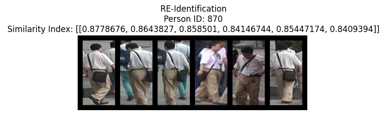

```
mAP considering similarity threshold of 0.7 : 1.0
```

```python
'''resnet50_FP16'''
# Load pre-trained ResNet-50 model (without the classification head)
interpreter = tf.lite.Interpreter('quantized_model_FP16.tflite')
interpreter.allocate_tensors()

# Get input and output tensors.
input_details = interpreter.get_input_details()
input_details
output_details = interpreter.get_output_details()

# Function to preprocess the image and extract features
def extract_features(image_path):
    # Load image for testing
    img = keras_image.load_img(image_path, target_size=(224, 224))
    img_array = keras_image.img_to_array(img)
    img_array = np.expand_dims(img_array, axis=0)
    img_array = preprocess_input(img_array)

    # Convert input data to float32 and set it to the input tensor
    input_data_f32 = np.array(img_array, dtype=np.float32)
    interpreter.set_tensor(input_details[0]['index'], input_data_f32)

    # Run inference and calculate latency
    interpreter.invoke()
    start = time.time()
    features = interpreter.get_tensor(output_details[0]['index'])
    latency = (time.time() - start) * 1000  # Multiply by 1000 to convert seconds to milliseconds
    print("Model Latency for ResNet50 model with FP16:", latency, "ms")
    return features.flatten()

# Function to preprocess the image and extract preticular person features
def query_person_feature_FP16(image_paths):
    person_features = []
    for image_path in image_paths:
        img = keras_image.load_img(image_path, target_size=(224, 224))
        img_array = keras_image.img_to_array(img)
        img_array = np.expand_dims(img_array, axis=0)
        img_array = preprocess_input(img_array)

        # Convert input data to float32 and set it to the input tensor
        input_data_f32 = np.array(img_array, dtype=np.float32)
        interpreter.set_tensor(input_details[0]['index'], input_data_f32)

        # Run inference and calculate latency
        interpreter.invoke()
        start = time.time()
        features = interpreter.get_tensor(output_details[0]['index'])
        latency = (time.time() - start) * 1000  # Multiply by 1000 to convert seconds to milliseconds
        print("Model Latency for ResNet50 model with FP16:", latency, "ms")
        person_features.append(features.flatten())

    # Calculate the mean feature vector for all images of the person
    if person_features:  # Check if the list is not empty
        mean_person_feature = np.mean(person_features, axis=0)
    else:
        mean_person_feature = np.array([])  # Empty array if no features were computed

    return mean_person_feature  # Return the mean feature vector for the person

# Calculate similarity between all images of the selected Person ID
similarities = []

# Extract features for the current image
features = query_person_feature_FP16(query_img_paths)
show_query_img(query_img_paths)

# Compare the features with all other images of the person
similarity_scores = []
for another_image_path in gallery_img_paths:
    another_features = extract_features(another_image_path)
    similarity = np.dot(features, another_features) / (np.linalg.norm(features) * np.linalg.norm(another_features))
    similarity_scores.append(similarity)

# Store similarity scores for each image
similarities.append(similarity_scores)
show_img(gallery_img_paths)

# Define the similarity threshold
threshold = 0.70

# Compute mAP and obtain true positives considering the specified threshold
mAP, true_positives = calculate_map(similarity_scores, threshold)
print("mAP considering similarity threshold of", threshold, ":", mAP)
```

# ResNet50 INT 8

```
Model Latency for ResNet50 model with FP16: 0.02193450927734375 ms
Model Latency for ResNet50 model with FP16: 0.035762786865234375 ms
Model Latency for ResNet50 model with FP16: 0.024080276489257812 ms
Model Latency for ResNet50 model with FP16: 0.03218650817871094 ms
```

```
Model Latency for ResNet50 model with INT16: 0.029325485229492188 ms
Model Latency for ResNet50 model with INT16: 0.0286102294921875 ms
Model Latency for ResNet50 model with INT16: 0.029802322387695312 ms
Model Latency for ResNet50 model with INT16: 0.029325485229492188 ms
Model Latency for ResNet50 model with INT16: 0.03361701965332031 ms
Model Latency for ResNet50 model with INT16: 0.027894973754882812 ms
```

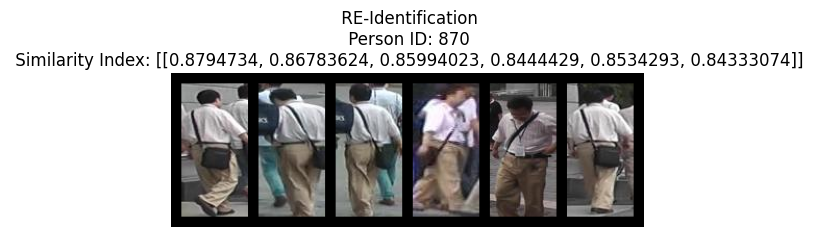

```
mAP considering similarity threshold of 0.7 : 1.0
```

```python
'''resnet50_INT8'''
# Load pre-trained ResNet-50 model (without the classification head)
interpreter = tf.lite.Interpreter('quantized_model_INT8.tflite')
interpreter.allocate_tensors()

# Get input and output tensors.
input_details = interpreter.get_input_details()
input_details
output_details = interpreter.get_output_details()

# Function to preprocess the image and extract features
def extract_features(image_path):
    # Load image for testing
    img = keras_image.load_img(image_path, target_size=(224, 224))
    img_array = keras_image.img_to_array(img)
    img_array = np.expand_dims(img_array, axis=0)
    img_array = preprocess_input(img_array)

    # Convert input data to float32 and set it to the input tensor
    input_data_f32 = np.array(img_array, dtype=np.float32)
    interpreter.set_tensor(input_details[0]['index'], input_data_f32)

    # Run inference and calculate latency
    interpreter.invoke()
    start = time.time()
    features = interpreter.get_tensor(output_details[0]['index'])
    latency = (time.time() - start) * 1000  # Multiply by 1000 to convert seconds to milliseconds
    print("Model Latency for ResNet50 model with INT16:", latency, "ms")
    return features.flatten()
# Function to preprocess the image and extract preticular person features
def query_person_feature_INT8(image_paths):
    person_features = []
    for image_path in image_paths:
        img = keras_image.load_img(image_path, target_size=(224, 224))
        img_array = keras_image.img_to_array(img)
        img_array = np.expand_dims(img_array, axis=0)
        img_array = preprocess_input(img_array)

        # Convert input data to float32 and set it to the input tensor
        input_data_f32 = np.array(img_array, dtype=np.float32)
        interpreter.set_tensor(input_details[0]['index'], input_data_f32)

        # Run inference and calculate latency
        interpreter.invoke()
        start = time.time()
        features = interpreter.get_tensor(output_details[0]['index'])
        latency = (time.time() - start) * 1000  # Multiply by 1000 to convert seconds to milliseconds
        print("Model Latency for ResNet50 model with FP16:", latency, "ms")
        person_features.append(features.flatten())

    # Calculate the mean feature vector for all images of the person
    if person_features:  # Check if the list is not empty
        mean_person_feature = np.mean(person_features, axis=0)
    else:
        mean_person_feature = np.array([])  # Empty array if no features were computed

    return mean_person_feature  # Return the mean feature vector for the person


# Calculate similarity between all images of the selected Person ID
similarities = []

# Extract features for the current image
features = query_person_feature_INT8(query_img_paths)
show_query_img(query_img_paths)

# Compare the features with all other images of the person
similarity_scores = []
for another_image_path in gallery_img_paths:
    another_features = extract_features(another_image_path)
    similarity = np.dot(features, another_features) / (np.linalg.norm(features) * np.linalg.norm(another_features))
    similarity_scores.append(similarity)

# Store similarity scores for each image
similarities.append(similarity_scores)
show_img(gallery_img_paths)

# Define the similarity threshold
threshold = 0.70

# Compute mAP and obtain true positives considering the specified threshold
mAP, true_positives = calculate_map(similarity_scores, threshold)
print("mAP considering similarity threshold of", threshold, ":", mAP)
```

# Conclusion:

Model : | ResNet50 | ResNet50_FP16 | ResNet50_INT8

Model Size: | 90.47 MB | 44.83 MB | 22.81 MB

# Problem 3. Write a custom loss function in tensorﬂow/keras to train a model for binary classiﬁcation and apply l2 reguralisation on only convolution and dense layers. Only the custom loss function is required as solution.

Loss functions, also called error functions, assess how close a model's predictions are to the actual target values. A lower loss indicates better model performance by showing that the model's predictions are closer to the desired target values. Below are some Loss function use for the Binary Class Classification

```python
import tensorflow as tf

def hinge_loss(y_true, y_pred):
    # Modify target labels to be in the set of {-1, 1}
    y_true = 2 * y_true - 1

    # Calculate Hinge Loss
    loss = tf.maximum(0., 1. - y_true * y_pred)

    return loss, tf.reduce_mean(loss)
```

### 2. Cross-Entropy/Logistic Loss (CE)

Cross-entropy loss, also called logistic loss, is frequently used in binary classification tasks with classes 0 and 1. It measures the difference between the actual class and the predicted value, usually ranging from 0 to 1. For best results. it's recommended to use the sigmoid activation function as the final layer before applying cross-entropy loss.

```python
'''sigmoid_cross_entropy_loss'''
def sigmoid_cross_entropy_loss(y_true, y_pred):
    # Apply sigmoid function to predicted values
    y_pred = tf.math.sigmoid(y_pred)

    # Clip values to avoid extremes of the log function
    y_pred = tf.clip_by_value(y_pred, 1e-7, 1 - 1e-7)

    # Compute the binary cross-entropy loss
    term_0 = y_true * tf.math.log(y_pred)
    term_1 = (1 - y_true) * tf.math.log(1 - y_pred)
    loss = -(term_0 + term_1)
    return tf.reduce_mean(loss)
```

```python
'''weighted_binary_crossentropy'''
def weighted_binary_crossentropy(y_true, y_pred, pos_weight):
    epsilon = 1e-7  # Small constant to avoid log(0) or log(1)

    # Clip predicted values to avoid log(0) or log(1)
    y_pred = tf.clip_by_value(y_pred, epsilon, 1 - epsilon)

    # Calculate binary cross-entropy loss with weights for positive class
    loss = - (pos_weight * y_true * tf.math.log(y_pred) + (1 - y_true) * tf.math.log(1 - y_pred))
    return tf.reduce_mean(loss)

'''Example usage with different weights'''
pos_weight_1 = 0.5
pos_weight_2 = 0.75

# Calculate weighted binary cross-entropy losses
weighted_loss_1 = weighted_binary_crossentropy(y_true, y_pred, pos_weight_1)
weighted_loss_2 = weighted_binary_crossentropy(y_true, y_pred, pos_weight_2)
```

## Custom loss function in tensorﬂow to train a model

```python
'''custom loss function in tensorﬂow/keras to train a model for binary classiﬁcation'''

def custom_loss_with_l2_reg(l2=0.01):
    # Binary cross-entropy loss function
    def custom_loss(y_true, y_pred):
        epsilon = 1e-7  # Small constant to avoid log(0) or log(1)

        # Clip values to avoid log(0) or log(1)
        y_pred = tf.clip_by_value(y_pred, epsilon, 1 - epsilon)

        # Calculate binary cross-entropy loss
        binary_loss = - (y_true * tf.math.log(y_pred) + (1 - y_true) * tf.math.log(1 - y_pred))
        binary_loss = tf.reduce_mean(binary_loss)

        # Calculate L2 regularization term
        l2_loss = tf.add_n([tf.nn.l2_loss(var) for var in tf.trainable_variables()])

        # Total loss with L2 regularization
        total_loss = binary_loss + l2 * l2_loss
        return total_loss

    return custom_loss


'''apply l2 reguralisation on only convolution and dense layers'''

# Create a Sequential model
model = tf.keras.Sequential([
    tf.keras.layers.Conv2D(32, (3, 3), activation='relu', input_shape=input_shape, kernel_regularizer=tf.keras.regularizers.l2(0.01)),
    tf.keras.layers.Conv2D(64, (3, 3), activation='relu', kernel_regularizer=tf.keras.regularizers.l2(0.01)),
    tf.keras.layers.Dropout(0.5),
    tf.keras.layers.MaxPooling2D((2, 2)),
    tf.keras.layers.Flatten(),
    tf.keras.layers.Dense(64, activation='relu', kernel_regularizer=tf.keras.regularizers.l2(0.01)),
    tf.keras.layers.Dense(1, activation='sigmoid')
])

# Compile the model
model.compile(optimizer='adam', loss=custom_loss_with_l2_reg(l2=0.01), metrics=['accuracy'])

# Display model summary
model.summary()
```

[output not shown]

#### Assessment:

1. Advantages:

Integrates binary cross-entropy for classification with L2 regularization in a single loss function. Offers control over model complexity to avoid overfitting.

2. Considerations:

The l2 parameter controls the strength of regularization and needs tuning based on dataset complexity. Effective for preventing overfitting while optimizing for binary classification. 3. Usage: Suitable for binary classification tasks requiring simultaneous optimization of cross-entropy and model regularization. 4. Flexibility: Provides flexibility to adjust the regularization strength for finding the right balance between fitting the data and controlling model complexity.

This combined loss function is useful for binary classification models, offering control over complexity while optimizing for accurate classification. Fine-tuning the regularization strength is crucial for optimal performance based on dataset characteristics and model complexity.